# notebook

Proyecto Final (Analisis Técnico)

MICROESTRUCTURA Y SISTEMAS DE TRADING

B.Eng Financial Engineering

I.F. Andrea Flores Fernández

I.F. Tania Bell Nicholls

I.F. Fernando Guerra Muro

I.F. Blas Cesar Sanchez Barba

May 2023 | Repository: [Link](https://github.com/if723286/MyST_LAB5_TEAM3)

LAB 5. Proyecto Final  
Análisis Técnico

Abstract

El análisis técnico se basa en la premisa de que patrones del pasado tienen probabilidad de volver a repetirse en el futuro. Aunque es cierto que es imposible predecir hacía dónde se moverá el mercado, también es cierto que si tu % de efectividad es lo suficientemente bueno, puedes ser rentable. Incluso si tu % de efectividad es bajo pero la relación riesgo-beneficio es alta, puedes tener una efectividad baja y aún así ser rentable.

La naturaleza del mercado de trading de divisas permite la utilización de herramientas para la generación de sistemas de trading. Este laboratorio se enfoca en generar un sistema de trading basado en un análisis técnico con el fin de generar inversiones basadas en señales. De esta manera se mejora la toma de decisiones al basarse en optimizaciones de funciones y del volumen, stop loss y take profit de cada operación.

## 1. Introducción

A través de este laboratorio, se pretende utilizar el análisis técnico como herramienta para la generación de oportunidades de trading. Mediante la combinación de dos indicadores de análisis técnico, se generará un sistema de trading que optimice la cantidad invertida en divisas, al igual que el stop loss y el take profit.

Se realizarán validaciones visuales del algoritmo de decisión generado con los indicadores y con la optimización de una función de utilidad.

Finalmente, se generará una tabla comparativa de los resultados con 3 medidas de atribución al desempeño.

## 2. Instalar/Cargar Paquetes y Dependencias

### 2.1 Python Packages

In order to run this notebook, it is necessary to have installed and/or have the *requirements.txt* file with the following:

- MetaTrader5
- pandas
- scipy
- numpy
- jupyter
- pytz
- datetime
- ta

### 2.2 Files Dependencies

The following are the file dependencies that are needed to run this notebook:

- files/EURUSD.csv : Precios históricos de EURUSD
- files/USDMXN.csv : Precios histróricos de USDMXN

### 2.3 Install Packages

```python
%%capture

# Install all the pip packages in the requirements.txt
import sys
!{sys.executable} -m pip install -r requirements.txt
```

```python
import pandas as pd
import numpy as np
import data as dt
import warnings
warnings.filterwarnings('ignore')
import functions as fc
```

## 3. Datos y validaciones

Los datos están dividos en dos secciones; periodo de entrenamiento y periodo de prueba. Las divisas elegidas para este laboratorio son EUR/USD y USD/MXN.

#### Periodo de entrenamiento: 01/ene/2020 - 01/ene/2021

```python
usdmxn_train = dt.usdmxn_train
usdmxn_train.drop(columns=usdmxn_train.columns[0], axis=1,  inplace=True)
usdmxn_train.head()
```

|  | time | open | high | low | close | tick_volume | spread | real_volume |
| --- | --- | --- | --- | --- | --- | --- | --- | --- |
| 1865 | 2020-01-02 00:00:00 | 18.89565 | 18.92847 | 18.82735 | 18.83095 | 50071 | 0 | 0 |
| 1866 | 2020-01-02 06:00:00 | 18.89660 | 18.89867 | 18.89565 | 18.89837 | 182 | 646 | 18200000 |
| 1867 | 2020-01-02 06:15:00 | 18.89837 | 18.90363 | 18.89767 | 18.90207 | 375 | 530 | 37500000 |
| 1868 | 2020-01-02 06:30:00 | 18.90207 | 18.90765 | 18.90187 | 18.90637 | 241 | 536 | 24100000 |
| 1869 | 2020-01-02 06:45:00 | 18.90637 | 18.91307 | 18.90637 | 18.91017 | 531 | 576 | 53100000 |

```python
eurusd_train = dt.eurusd_train
eurusd_train.drop(columns=eurusd_train.columns[0], axis=1,  inplace=True)
eurusd_train.head()
```

|  | time | open | high | low | close | tick_volume | spread | real_volume |
| --- | --- | --- | --- | --- | --- | --- | --- | --- |
| 2110 | 2020-01-02 00:00:00 | 1.12080 | 1.12140 | 1.11628 | 1.11712 | 36043 | 50 | 0 |
| 2111 | 2020-01-02 06:00:00 | 1.12124 | 1.12135 | 1.12117 | 1.12135 | 2963 | 15 | 444450000 |
| 2112 | 2020-01-02 06:15:00 | 1.12135 | 1.12136 | 1.12112 | 1.12114 | 3639 | 15 | 545850000 |
| 2113 | 2020-01-02 06:30:00 | 1.12114 | 1.12115 | 1.12082 | 1.12090 | 3489 | 15 | 523350000 |
| 2114 | 2020-01-02 06:45:00 | 1.12090 | 1.12090 | 1.12002 | 1.12005 | 4789 | 15 | 718350000 |

```python
usdmxn_test = dt.usdmxn_test
usdmxn_test.drop(columns=usdmxn_test.columns[0], axis=1,  inplace=True)
usdmxn_test.head()
```

|  | time | open | high | low | close | tick_volume | spread | real_volume |
| --- | --- | --- | --- | --- | --- | --- | --- | --- |
| 26696 | 2021-01-04 00:00:00 | 19.89975 | 19.97963 | 19.70202 | 19.89975 | 118631 | 0 | 2100000 |
| 26697 | 2021-01-04 00:15:00 | 19.89725 | 19.89750 | 19.89500 | 19.89500 | 75 | 2500 | 7500000 |
| 26698 | 2021-01-04 00:30:00 | 19.89500 | 19.89750 | 19.89200 | 19.89301 | 65 | 2500 | 6500000 |
| 26699 | 2021-01-04 00:45:00 | 19.89301 | 19.89307 | 19.89301 | 19.89307 | 52 | 2500 | 5200000 |
| 26700 | 2021-01-04 01:00:00 | 19.89307 | 19.89504 | 19.84544 | 19.85333 | 1203 | 2485 | 120300000 |

```python
eurusd_test = dt.eurusd_test
eurusd_test.drop(columns=eurusd_test.columns[0], axis=1,  inplace=True)
eurusd_test.head()
```

|  | time | open | high | low | close | tick_volume | spread | real_volume |
| --- | --- | --- | --- | --- | --- | --- | --- | --- |
| 27007 | 2021-01-04 00:00:00 | 1.22379 | 1.22384 | 1.22291 | 1.22293 | 668 | 15 | 100200000 |
| 27008 | 2021-01-04 00:15:00 | 1.22293 | 1.22370 | 1.22293 | 1.22340 | 520 | 17 | 78000000 |
| 27009 | 2021-01-04 00:30:00 | 1.22340 | 1.22384 | 1.22322 | 1.22343 | 927 | 15 | 139050000 |
| 27010 | 2021-01-04 00:45:00 | 1.22343 | 1.22353 | 1.22325 | 1.22334 | 309 | 15 | 46350000 |
| 27011 | 2021-01-04 01:00:00 | 1.22334 | 1.22410 | 1.22302 | 1.22391 | 6232 | 15 | 934800000 |

## 4. Aspectos financieros

### Sistema de trading

Un sistema de trading es un conjunto de reglas que le indican al trader cuándo operar. Se basan en análisis técnico para poder determinar el momento más rentable para entrar al mercado y cuándo es el mejor momento para salir. El sistema también puede indicarle cuánto debe operar en cada transacción.

Los sistemas de trading son la base para las inversiones ya que permiten determinar cuándo abrir una posición, su tamaño y el tiempo que deberá permanecer abierta. Incluso pueden definir la gestión de la posición mientras se desarrolla, las técnicas de control de riesgo, los cálculos de gestión de capital, la diversificación del portafolio, entre otros aspectos.

Según las ideas de Irene Aldridge, un sistema general debería de incluir los siguientes elementos: la gestión de datos, un sistema de generación de señales, un sistema de seguimiento de la cartera junto con sus pérdidas y ganancias y un sistema de gestión de riesgos cuantitativo. También se puede incluir dentro de estos elementos un sistema de ejecución.

Los sistemas pueden ser manuales o automatizados y se basan en diferentes técnicas y metodologías de análisis de mercado. Estas técnicas pueden basarse en el análisis técnico, análisis fundamental o análisis cuantitativo. En este laboratorio se realiza un análisis técnico.

### Aspectos Estadísticos

#### Bandas de Bollinger

Las bandas de bollinger son una herramienta de análisis técnico definidas por un conjunto de líneas de tendencia. Se grafican dos desviaciones estándares, tanto positivas como negativas, de una media móvil simple del precio de un valor. Fueron desarrolladas por John Bollinger para proporcionar a los traders una manera de identificar los periodos de alta y baja probabilidad de cambio.

La franja entre las bandas superior e inferior contiene, estadísticamente, casi un 90% de las posibles variaciones del precio. Las bandas son utilizadas para identificar cambios de tendencia en el precio e identificar fortaleza o debilidad en la misma.

```python
fc.bollinger(usdmxn_train)[0].iloc[20:31]
```

|  | time | open | high | low | close | tick_volume | spread | real_volume | middle | upper | lower | upper_signal | lower_signal |
| --- | --- | --- | --- | --- | --- | --- | --- | --- | --- | --- | --- | --- | --- |
| 1885 | 2020-01-02 10:45:00 | 18.86446 | 18.86567 | 18.85297 | 18.85662 | 1395 | 530 | 139500000 | 18.901844 | 18.938578 | 18.865111 | 0.0 | 1.0 |
| 1886 | 2020-01-02 11:00:00 | 18.85662 | 18.86695 | 18.85623 | 18.86127 | 1445 | 530 | 144500000 | 18.899989 | 18.940763 | 18.859216 | 0.0 | 0.0 |
| 1887 | 2020-01-02 11:15:00 | 18.86137 | 18.86497 | 18.85683 | 18.85827 | 1135 | 530 | 113500000 | 18.897799 | 18.942415 | 18.853184 | 0.0 | 0.0 |
| 1888 | 2020-01-02 11:30:00 | 18.85837 | 18.86627 | 18.85208 | 18.86567 | 1362 | 530 | 136200000 | 18.895765 | 18.942302 | 18.849227 | 0.0 | 0.0 |
| 1889 | 2020-01-02 11:45:00 | 18.86567 | 18.87017 | 18.86487 | 18.86887 | 966 | 530 | 96600000 | 18.893700 | 18.941153 | 18.846246 | 0.0 | 0.0 |
| 1890 | 2020-01-02 12:00:00 | 18.86887 | 18.87273 | 18.86800 | 18.87230 | 927 | 530 | 92700000 | 18.891391 | 18.938288 | 18.844494 | 0.0 | 0.0 |
| 1891 | 2020-01-02 12:15:00 | 18.87230 | 18.88036 | 18.86907 | 18.88036 | 1205 | 530 | 120500000 | 18.889371 | 18.934479 | 18.844262 | 0.0 | 0.0 |
| 1892 | 2020-01-02 12:30:00 | 18.88036 | 18.89965 | 18.88001 | 18.89188 | 1519 | 530 | 151900000 | 18.888061 | 18.931240 | 18.844882 | 0.0 | 0.0 |
| 1893 | 2020-01-02 12:45:00 | 18.89188 | 18.89863 | 18.89188 | 18.89463 | 1482 | 530 | 148200000 | 18.887334 | 18.929546 | 18.845122 | 0.0 | 0.0 |
| 1894 | 2020-01-02 13:00:00 | 18.89463 | 18.89587 | 18.87097 | 18.87557 | 1448 | 556 | 144800000 | 18.885459 | 18.926238 | 18.844680 | 0.0 | 0.0 |
| 1895 | 2020-01-02 13:15:00 | 18.87587 | 18.87828 | 18.87433 | 18.87787 | 1377 | 566 | 137700000 | 18.883544 | 18.921900 | 18.845188 | 0.0 | 0.0 |

```python
fc.bollinger(eurusd_train)[0].iloc[20:31]
```

|  | time | open | high | low | close | tick_volume | spread | real_volume | middle | upper | lower | upper_signal | lower_signal |
| --- | --- | --- | --- | --- | --- | --- | --- | --- | --- | --- | --- | --- | --- |
| 2130 | 2020-01-02 10:45:00 | 1.12083 | 1.12118 | 1.12078 | 1.12113 | 7666 | 15 | 1149900000 | 1.120650 | 1.121356 | 1.119944 | 0.0 | 0.0 |
| 2131 | 2020-01-02 11:00:00 | 1.12111 | 1.12133 | 1.12086 | 1.12099 | 6766 | 15 | 1014900000 | 1.120632 | 1.121282 | 1.119982 | 0.0 | 0.0 |
| 2132 | 2020-01-02 11:15:00 | 1.12099 | 1.12113 | 1.12089 | 1.12093 | 5115 | 15 | 767250000 | 1.120621 | 1.121245 | 1.119998 | 0.0 | 0.0 |
| 2133 | 2020-01-02 11:30:00 | 1.12093 | 1.12104 | 1.12045 | 1.12050 | 5840 | 15 | 876000000 | 1.120602 | 1.121213 | 1.119990 | 0.0 | 0.0 |
| 2134 | 2020-01-02 11:45:00 | 1.12050 | 1.12052 | 1.12005 | 1.12023 | 6449 | 15 | 967350000 | 1.120610 | 1.121194 | 1.120027 | 0.0 | 0.0 |
| 2135 | 2020-01-02 12:00:00 | 1.12023 | 1.12031 | 1.12003 | 1.12005 | 6150 | 15 | 922500000 | 1.120610 | 1.121196 | 1.120024 | 0.0 | 0.0 |
| 2136 | 2020-01-02 12:15:00 | 1.12005 | 1.12005 | 1.11920 | 1.11925 | 7325 | 15 | 1098750000 | 1.120567 | 1.121377 | 1.119757 | 0.0 | 1.0 |
| 2137 | 2020-01-02 12:30:00 | 1.11925 | 1.11954 | 1.11921 | 1.11933 | 6392 | 15 | 958800000 | 1.120522 | 1.121487 | 1.119557 | 0.0 | 1.0 |
| 2138 | 2020-01-02 12:45:00 | 1.11933 | 1.11991 | 1.11929 | 1.11976 | 5336 | 15 | 800400000 | 1.120492 | 1.121511 | 1.119473 | 0.0 | 0.0 |
| 2139 | 2020-01-02 13:00:00 | 1.11976 | 1.12015 | 1.11961 | 1.11997 | 6786 | 15 | 1017900000 | 1.120459 | 1.121501 | 1.119418 | 0.0 | 0.0 |
| 2140 | 2020-01-02 13:15:00 | 1.11997 | 1.11997 | 1.11933 | 1.11940 | 6457 | 15 | 968550000 | 1.120406 | 1.121545 | 1.119267 | 0.0 | 0.0 |

#### Relative Strength Index (RSI)

El RSI mide el impulso de los cambios en el precio de un activo para evaluar si el precio de dicho activo está sobrevendido o sobrecomprado. Este indicador es parte de la categoría de los osciladores y fue creado por J. Welles Wilder Jr.

El RSI se calcula mediante la siguiente fórmula:

$RSI=100-\frac{100}{1+RS}$

en donde

$RS=\frac{Avg Up}{Avg Down}$

siendo:

$Avg Up$ el promedio de las variaciones al alza del precio en el periodo N y $Avg Down$ el promedio de las variaciones a la baja del precio en el periodo N.

Habitualmente, se considera un periodo de 14 para el cálculo del RSI.

Para obtener señales de trading con el RSI se puede hacer mediante la identificación de divergencias o mediante el análisis de formaciones de doble fondo.

```python
fc.rsi(usdmxn_train)[0].iloc[20:31]
```

|  | time | open | high | low | close | tick_volume | spread | real_volume | middle | upper | lower | upper_signal | lower_signal | rsi | rsi_upper | rsi_lower |
| --- | --- | --- | --- | --- | --- | --- | --- | --- | --- | --- | --- | --- | --- | --- | --- | --- |
| 1885 | 2020-01-02 10:45:00 | 18.86446 | 18.86567 | 18.85297 | 18.85662 | 1395 | 530 | 139500000 | 18.901844 | 18.938578 | 18.865111 | 0.0 | 1.0 | NaN | 80 | 20 |
| 1886 | 2020-01-02 11:00:00 | 18.85662 | 18.86695 | 18.85623 | 18.86127 | 1445 | 530 | 144500000 | 18.899989 | 18.940763 | 18.859216 | 0.0 | 0.0 | NaN | 80 | 20 |
| 1887 | 2020-01-02 11:15:00 | 18.86137 | 18.86497 | 18.85683 | 18.85827 | 1135 | 530 | 113500000 | 18.897799 | 18.942415 | 18.853184 | 0.0 | 0.0 | NaN | 80 | 20 |
| 1888 | 2020-01-02 11:30:00 | 18.85837 | 18.86627 | 18.85208 | 18.86567 | 1362 | 530 | 136200000 | 18.895765 | 18.942302 | 18.849227 | 0.0 | 0.0 | NaN | 80 | 20 |
| 1889 | 2020-01-02 11:45:00 | 18.86567 | 18.87017 | 18.86487 | 18.86887 | 966 | 530 | 96600000 | 18.893700 | 18.941153 | 18.846246 | 0.0 | 0.0 | 50.419793 | 80 | 20 |
| 1890 | 2020-01-02 12:00:00 | 18.86887 | 18.87273 | 18.86800 | 18.87230 | 927 | 530 | 92700000 | 18.891391 | 18.938288 | 18.844494 | 0.0 | 0.0 | 51.995140 | 80 | 20 |
| 1891 | 2020-01-02 12:15:00 | 18.87230 | 18.88036 | 18.86907 | 18.88036 | 1205 | 530 | 120500000 | 18.889371 | 18.934479 | 18.844262 | 0.0 | 0.0 | 55.459275 | 80 | 20 |
| 1892 | 2020-01-02 12:30:00 | 18.88036 | 18.89965 | 18.88001 | 18.89188 | 1519 | 530 | 151900000 | 18.888061 | 18.931240 | 18.844882 | 0.0 | 0.0 | 59.780370 | 80 | 20 |
| 1893 | 2020-01-02 12:45:00 | 18.89188 | 18.89863 | 18.89188 | 18.89463 | 1482 | 530 | 148200000 | 18.887334 | 18.929546 | 18.845122 | 0.0 | 0.0 | 60.727766 | 80 | 20 |
| 1894 | 2020-01-02 13:00:00 | 18.89463 | 18.89587 | 18.87097 | 18.87557 | 1448 | 556 | 144800000 | 18.885459 | 18.926238 | 18.844680 | 0.0 | 0.0 | 51.901239 | 80 | 20 |
| 1895 | 2020-01-02 13:15:00 | 18.87587 | 18.87828 | 18.87433 | 18.87787 | 1377 | 566 | 137700000 | 18.883544 | 18.921900 | 18.845188 | 0.0 | 0.0 | 52.764232 | 80 | 20 |

```python
fc.rsi(eurusd_train)[0].iloc[20:31]
```

|  | time | open | high | low | close | tick_volume | spread | real_volume | middle | upper | lower | upper_signal | lower_signal | rsi | rsi_upper | rsi_lower |
| --- | --- | --- | --- | --- | --- | --- | --- | --- | --- | --- | --- | --- | --- | --- | --- | --- |
| 2130 | 2020-01-02 10:45:00 | 1.12083 | 1.12118 | 1.12078 | 1.12113 | 7666 | 15 | 1149900000 | 1.120650 | 1.121356 | 1.119944 | 0.0 | 0.0 | NaN | 80 | 20 |
| 2131 | 2020-01-02 11:00:00 | 1.12111 | 1.12133 | 1.12086 | 1.12099 | 6766 | 15 | 1014900000 | 1.120632 | 1.121282 | 1.119982 | 0.0 | 0.0 | NaN | 80 | 20 |
| 2132 | 2020-01-02 11:15:00 | 1.12099 | 1.12113 | 1.12089 | 1.12093 | 5115 | 15 | 767250000 | 1.120621 | 1.121245 | 1.119998 | 0.0 | 0.0 | NaN | 80 | 20 |
| 2133 | 2020-01-02 11:30:00 | 1.12093 | 1.12104 | 1.12045 | 1.12050 | 5840 | 15 | 876000000 | 1.120602 | 1.121213 | 1.119990 | 0.0 | 0.0 | NaN | 80 | 20 |
| 2134 | 2020-01-02 11:45:00 | 1.12050 | 1.12052 | 1.12005 | 1.12023 | 6449 | 15 | 967350000 | 1.120610 | 1.121194 | 1.120027 | 0.0 | 0.0 | 60.326889 | 80 | 20 |
| 2135 | 2020-01-02 12:00:00 | 1.12023 | 1.12031 | 1.12003 | 1.12005 | 6150 | 15 | 922500000 | 1.120610 | 1.121196 | 1.120024 | 0.0 | 0.0 | 57.920788 | 80 | 20 |
| 2136 | 2020-01-02 12:15:00 | 1.12005 | 1.12005 | 1.11920 | 1.11925 | 7325 | 15 | 1098750000 | 1.120567 | 1.121377 | 1.119757 | 0.0 | 1.0 | 48.892748 | 80 | 20 |
| 2137 | 2020-01-02 12:30:00 | 1.11925 | 1.11954 | 1.11921 | 1.11933 | 6392 | 15 | 958800000 | 1.120522 | 1.121487 | 1.119557 | 0.0 | 1.0 | 49.709285 | 80 | 20 |
| 2138 | 2020-01-02 12:45:00 | 1.11933 | 1.11991 | 1.11929 | 1.11976 | 5336 | 15 | 800400000 | 1.120492 | 1.121511 | 1.119473 | 0.0 | 0.0 | 53.838611 | 80 | 20 |
| 2139 | 2020-01-02 13:00:00 | 1.11976 | 1.12015 | 1.11961 | 1.11997 | 6786 | 15 | 1017900000 | 1.120459 | 1.121501 | 1.119418 | 0.0 | 0.0 | 55.689489 | 80 | 20 |
| 2140 | 2020-01-02 13:15:00 | 1.11997 | 1.11997 | 1.11933 | 1.11940 | 6457 | 15 | 968550000 | 1.120406 | 1.121545 | 1.119267 | 0.0 | 0.0 | 50.019027 | 80 | 20 |

#### Generación de señal de compra o de venta

Para este laboratorio, la señal de compra o de venta se generó basada en las bandas de bollinger y el RSI. Si estos dos indicadores marcan una compra, se realiza la compra y lo mismo va para la venta. Pero si los indicadores tienen señales distintas, se respeta la señal generada por las bandas de bollinger

```python
fc.signal(usdmxn_train)
```

```
'Buy'
```

```python
fc.signal(eurusd_train)
```

```
'Sell'
```

#### Visualización de algoritmo

Para realizar una validación visual del algoritmo se presentan a continuación las gráficas de las Bandas de Bollinger y del RSI.

```python
fc.bollinger(usdmxn_train)[1]
```

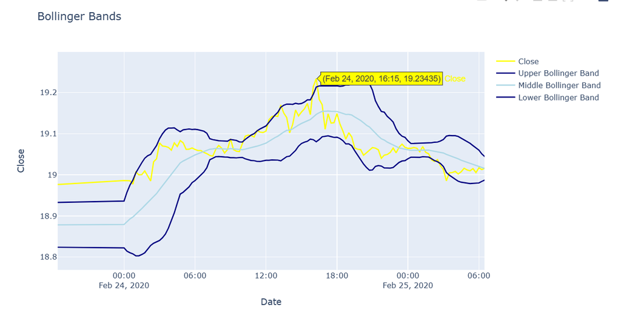

```python
fc.bollinger(eurusd_train)[1]
```

Una señal de compra se generaría en el tiempo 03:45 del 28 de septiembre del 2020 ya que el precio cruza la banda inferior. Esto nos indica que llegó a un precio menor que el promedio inferior y por ende es probable que el precio suba.

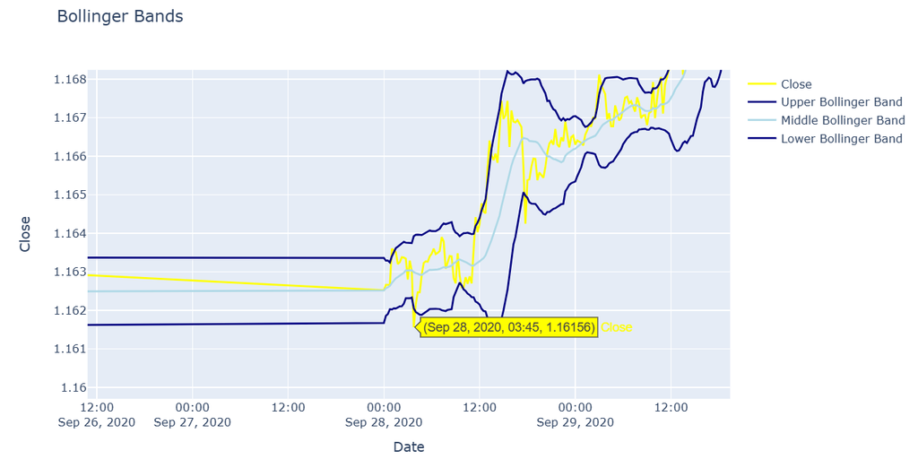

```python
fc.rsi(usdmxn_train)[1]
```

[output not shown]

```python
fc.rsi(eurusd_train)[1]
```

[output not shown]

## 5. Aspectos Computacionales: Entrenamiento

#### Parámetros a optimizar

**a)** Stop Loss:

· Qué es: Cantidad de pips en contra de dónde se abrió la operación.

· Expresado en: Pips (valor numérico %)

**b)** Take Profit:

· Qué es: Cantidad de pips que se mueve a favor tu operación para cerrarla y tomar ganancias.

· Expresado en: Pips (valor numérico %)

**c)** Volumen:

· Qué es: Tamaño de operación (Lotes, % del capital total, etc)

· Expresado en: Valor númerico

#### Método de optimización

Para la optimización de los parámetros se usan dos diferentes métodos; la búsqueda exhaustiva y el PSO.

#### Búsqueda exhaustiva:

Mediante esta optimización se tiene el objetivo de encontrar los mejores parámetros a través de pruebas de distintos valores dentro de un rango que pudiera contener los parámetros óptimos. A través de múltiples pruebas con diferentes parámetros, se eligen los que tengan mejor rendimiento.

#### PSO:

El PSO, o Optimización por Enjambre de Partículas, es un método heurístico de optimización que imita el comportamiento natural para resolver problemas. Este algoritmo se basa en una población de soluciones candidatas llamadas "partículas", que se mueven a través del espacio de búsqueda siguiendo reglas matemáticas que consideran tanto la posición como la velocidad de cada partícula. Cada partícula se ve influenciada por su mejor posición local y las mejores posiciones globales encontradas por otras partículas en su recorrido. El objetivo es lograr que el enjambre de partículas converja rápidamente hacia las soluciones más óptimas.

```python
results_usdmxn = fc.automated_trading(usdmxn_train, window_length=15, k=3, rsi_window=1, volume=1000, stop_loss=0.03, take_profit=0.3)[-1]
results_usdmxn
```

|  | type | open_price | amount | value | stop_loss | take_profit | pnl | balance |
| --- | --- | --- | --- | --- | --- | --- | --- | --- |
| 0 | long | 18.90955 | 1000 | 18909.55 | 18.342263 | 24.582415 | 0 | 81090.45 |
| 1 | short | 18.79245 | 1000 | 18792.45 | 18.228676 | 24.430185 | -117.1 | 99882.90 |
| 3 | long | 18.78695 | 1000 | 18786.95 | 18.223342 | 24.423035 | 0 | 81095.95 |
| 5 | short | 18.76565 | 1000 | 18765.65 | 18.202680 | 24.395345 | -21.3 | 99861.60 |
| 7 | long | 18.90385 | 1000 | 18903.85 | 18.336734 | 24.575005 | 0 | 80957.75 |
| 12 | short | 23.33664 | 1000 | 23336.64 | 22.636541 | 30.337632 | 4432.79 | 104294.39 |
| 13 | long | 24.97268 | 1000 | 24972.68 | 24.223500 | 32.464484 | 0 | 79321.71 |
| 14 | short | 23.30000 | 1000 | 23300.00 | 22.601000 | 30.290000 | -1672.68 | 102621.71 |
| 15 | long | 23.69588 | 1000 | 23695.88 | 22.985004 | 30.804644 | 0 | 78925.83 |
| 17 | short | 24.59833 | 1000 | 24598.33 | 23.860380 | 31.977829 | 902.45 | 103524.16 |
| 19 | long | 23.93425 | 1000 | 23934.25 | 23.216222 | 31.114525 | 0 | 79589.91 |
| 20 | short | 22.72520 | 1000 | 22725.20 | 22.043444 | 29.542760 | -1209.05 | 102315.11 |
| 23 | long | 22.23060 | 1000 | 22230.60 | 21.563682 | 28.899780 | 0 | 80084.51 |
| 26 | short | 22.37220 | 1000 | 22372.20 | 21.701034 | 29.083860 | 141.6 | 102456.71 |
| 27 | long | 22.43865 | 1000 | 22438.65 | 21.765490 | 29.170245 | 0 | 80018.06 |
| 29 | short | 22.27456 | 1000 | 22274.56 | 21.606323 | 28.956928 | -164.09 | 102292.62 |
| 31 | long | 22.35977 | 1000 | 22359.77 | 21.688977 | 29.067701 | 0 | 79932.85 |
| 32 | short | 21.98200 | 1000 | 21982.00 | 21.322540 | 28.576600 | -377.77 | 101914.85 |
| 38 | long | 22.33900 | 1000 | 22339.00 | 21.668830 | 29.040700 | 0 | 79575.85 |
| 39 | short | 21.62298 | 1000 | 21622.98 | 20.974291 | 28.109874 | -716.02 | 101198.83 |
| 43 | long | 21.17250 | 1000 | 21172.50 | 20.537325 | 27.524250 | 0 | 80026.33 |
| 44 | short | 20.58845 | 1000 | 20588.45 | 19.970797 | 26.764985 | -584.05 | 100614.78 |
| 49 | long | 20.13240 | 1000 | 20132.40 | 19.528428 | 26.172120 | 0 | 80482.38 |
| 50 | short | 19.94600 | 1000 | 19946.00 | 19.347620 | 25.929800 | -186.4 | 100428.38 |
| 52 | long | 19.94113 | 1000 | 19941.13 | 19.342896 | 25.923469 | 0 | 80487.25 |
| 52 | NaN | 19.94113 | 1000 | 19941.13 | 0.030000 | 0.300000 | 0 | 100428.38 |

```python
best_params_usdmxn = fc.optimize_parameters(usdmxn_train,max_volume=100000, max_stop_loss=0.5, max_take_profit=0.5)
best_params_usdmxn
```

```
(100000.0, 0.01, 0.17333333333333334, 250511.00000000047)
```

```python
best_params_pso_usdmxn = fc.optimize_parameters_pso(usdmxn_train, max_volume=10000, max_stop_loss=0.05, max_take_profit=0.1, num_particles=10, num_iterations=10)
best_params_pso_usdmxn
```

```
2023-05-10 19:19:45,042 - pyswarms.single.global_best - INFO - Optimize for 10 iters with {'c1': 0.5, 'c2': 0.3, 'w': 0.9}
2023-05-10 19:22:51,711 - pyswarms.single.global_best - INFO - Optimization finished | best cost: -100634.12558949832, best pos: [8.65109945e+03 9.90275542e-03 4.29736652e-02]
```

```
(100634.12558949832, array([8.65109945e+03, 9.90275542e-03, 4.29736652e-02]))
```

```python
results_eurusd = fc.automated_trading(eurusd_train, window_length=15, k=3, rsi_window=1, volume=1000, stop_loss=0.03, take_profit=0.3)[-1]
results_eurusd
```

|  | type | open_price | amount | value | stop_loss | take_profit | pnl | balance |
| --- | --- | --- | --- | --- | --- | --- | --- | --- |
| 0 | long | 1.11601 | 1000 | 1116.01 | 1.082530 | 1.450813 | 0 | 98883.99 |
| 1 | short | 1.11195 | 1000 | 1111.95 | 1.078591 | 1.445535 | -4.06 | 99995.94 |
| 4 | long | 1.10911 | 1000 | 1109.11 | 1.075837 | 1.441843 | 0 | 98886.83 |
| 5 | short | 1.09442 | 1000 | 1094.42 | 1.061587 | 1.422746 | -14.69 | 99981.25 |
| 7 | long | 1.08468 | 1000 | 1084.68 | 1.052140 | 1.410084 | 0 | 98896.57 |
| 10 | short | 1.11124 | 1000 | 1111.24 | 1.077903 | 1.444612 | 26.56 | 100007.81 |
| 12 | long | 1.11396 | 1000 | 1113.96 | 1.080541 | 1.448148 | 0 | 98893.85 |
| 13 | short | 1.08001 | 1000 | 1080.01 | 1.047610 | 1.404013 | -33.95 | 99973.86 |
| 14 | long | 1.09358 | 1000 | 1093.58 | 1.060773 | 1.421654 | 0 | 98880.28 |
| 15 | short | 1.08748 | 1000 | 1087.48 | 1.054856 | 1.413724 | -6.1 | 99967.76 |
| 17 | long | 1.09806 | 1000 | 1098.06 | 1.065118 | 1.427478 | 0 | 98869.70 |
| 18 | short | 1.08352 | 1000 | 1083.52 | 1.051014 | 1.408576 | -14.54 | 99953.22 |
| 20 | long | 1.09010 | 1000 | 1090.10 | 1.057397 | 1.417130 | 0 | 98863.12 |
| 23 | short | 1.12548 | 1000 | 1125.48 | 1.091716 | 1.463124 | 35.38 | 99988.60 |
| 25 | long | 1.12185 | 1000 | 1121.85 | 1.088194 | 1.458405 | 0 | 98866.75 |
| 33 | short | 1.17961 | 1000 | 1179.61 | 1.144222 | 1.533493 | 57.76 | 100046.36 |
| 34 | long | 1.19035 | 1000 | 1190.35 | 1.154640 | 1.547455 | 0 | 98856.01 |
| 35 | short | 1.18376 | 1000 | 1183.76 | 1.148247 | 1.538888 | -6.59 | 100039.77 |
| 36 | long | 1.18461 | 1000 | 1184.61 | 1.149072 | 1.539993 | 0 | 98855.16 |
| 37 | short | 1.18407 | 1000 | 1184.07 | 1.148548 | 1.539291 | -0.54 | 100039.23 |
| 39 | long | 1.17168 | 1000 | 1171.68 | 1.136530 | 1.523184 | 0 | 98867.55 |
| 41 | short | 1.17191 | 1000 | 1171.91 | 1.136753 | 1.523483 | 0.23 | 100039.46 |
| 42 | long | 1.18611 | 1000 | 1186.11 | 1.150527 | 1.541943 | 0 | 98853.35 |
| 43 | short | 1.16453 | 1000 | 1164.53 | 1.129594 | 1.513889 | -21.58 | 100017.88 |
| 44 | long | 1.18756 | 1000 | 1187.56 | 1.151933 | 1.543828 | 0 | 98830.32 |
| 45 | short | 1.18352 | 1000 | 1183.52 | 1.148014 | 1.538576 | -4.04 | 100013.84 |
| 46 | long | 1.18625 | 1000 | 1186.25 | 1.150662 | 1.542125 | 0 | 98827.59 |
| 49 | short | 1.21120 | 1000 | 1211.20 | 1.174864 | 1.574560 | 24.95 | 100038.79 |
| 50 | long | 1.22549 | 1000 | 1225.49 | 1.188725 | 1.593137 | 0 | 98813.30 |
| 51 | short | 1.21805 | 1000 | 1218.05 | 1.181509 | 1.583465 | -7.44 | 100031.35 |
| 52 | long | 1.22161 | 1000 | 1221.61 | 1.184962 | 1.588093 | 0 | 98809.74 |
| 52 | NaN | 1.22161 | 1000 | 1221.61 | 0.030000 | 0.300000 | 0 | 100031.35 |

```python
best_params_eurusd = fc.optimize_parameters(eurusd_train,max_volume=100000, max_stop_loss=0.5, max_take_profit=0.5)
best_params_eurusd
```

```
(100000.0, 0.01, 0.06444444444444444, 103134.99999999996)
```

```python
best_params_pso_eurusd = fc.optimize_parameters_pso(eurusd_train, max_volume=10000, max_stop_loss=0.05, max_take_profit=0.1, num_particles=10, num_iterations=10)
best_params_pso_eurusd
```

```
2023-05-10 19:50:31,932 - pyswarms.single.global_best - INFO - Optimize for 10 iters with {'c1': 0.5, 'c2': 0.3, 'w': 0.9}
2023-05-10 19:53:04,857 - pyswarms.single.global_best - INFO - Optimization finished | best cost: -100368.18508417695, best pos: [9.24159348e+03 3.96169434e-02 3.22087971e-02]
```

```
(100368.18508417695, array([9.24159348e+03, 3.96169434e-02, 3.22087971e-02]))
```

```python
fc.mad(results_usdmxn,0.01277)
```

|  | Media Aritmética | Media Geométrica | Radio de Sharpe |
| --- | --- | --- | --- |
| 0 | 3.75515 | -15.540309 | 0.151547 |

```python
fc.mad(results_eurusd,0.01277)
```

|  | Media Aritmética | Media Geométrica | Radio de Sharpe |
| --- | --- | --- | --- |
| 0 | 0.043925 | -13.372343 | 0.026469 |